# Lab 6: Simulating data from a complex DAG

Author

Jesse Brunner

Published

February 4, 2025

We’ve now gotten fairly comfortable simulating data. Let’s use our tools, then, to explore the consequences of different causal structures. That is, let’s simulate data from a known, but complex DAG and then see what happens when we include (=condition on) certain (sets of) variables in our analyses!

# Example 1: Viral growth in an experiment

Viruses are super interesting and, setting aside a whole bunch of complications like virology and immunology, pretty easy to think about. Let’s imagine that we’re interested in the influence of food availability and temperature on the resulting viral concentration or titer in some ectothermic hosts[^1]. Indeed, let’s imagine that we conducted an experiment where we raised our hosts in low, mean, or hot conditions with low, mean, or high amounts of food.

We might think of food availability increasing the energy reserves the host has to mount an effective immune response with which to fight against the virus population growing within it. So food might indirectly, through its influence on energetic reserves, decrease viral titers. We might also imagine that temperature tends to increase the metabolism of the host, and thus reduces the energy reserves. Moreover, viral replication rates likely increase with temperature, so that temperature has a direct effect on viral titers[^2]

Unfortunately, we cannot measure energetic reserves directly, but we can measure things like body condition. For instance, we might use a ratio of weight to length of our host to indicated how fat a host is, presuming that individuals with more energetic reserves are heavier for their length.

This is how we might represent this causal story in the form of a DAG.

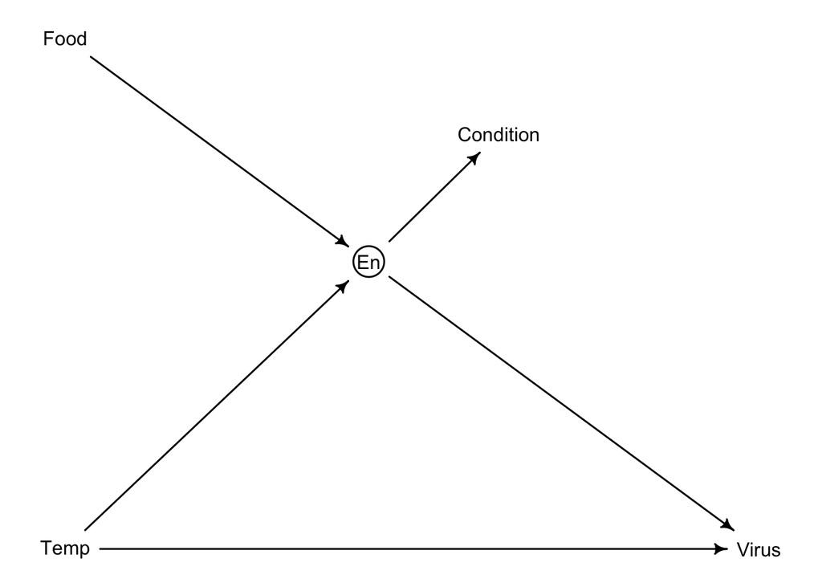

```r
library(dagitty)
library(rethinking)

virus <- dagitty("dag{
Food -> En -> Virus
En <- Temp -> Virus
En -> Condition

En [unobserved]
}")
coordinates(virus) <- list(
  x=c(Food=1, En=4.5, Condition=6, Temp=1, Virus = 9),
  y=c(Food=1, En=4.5, Condition=2.5, Temp=9, Virus = 9))
drawdag(virus)
```

```r
dev.off() # <--  drawdag() messes with the plotting canvas, so reset it
```

Now, if we had measured these variables (or set the values of food and temperature) and were interested in the effects of food or temperature on virus titers in hosts, what should we include or condition on in our model? Or, more to the point, would it be a good or bad idea to include body condition as a predictor?

Before proceeding, think about what you would do.

.  
.  
.

We have seen that we can use some functions in the `daggity` package to see what our DAG can tell us. Let’s try some.

```r
impliedConditionalIndependencies(virus)
```

```
Food _||_ Temp
```

This tells us that if our DAG were correct then food and temperature should be independent. That’s perhaps good to know, but since we designed the (fake) experiment, we knew this would be the case. So, not so useful in this case. Let’s try the other function.

```r
adjustmentSets(virus,
               exposure = "Food",
               outcome = "Virus",
               effect = "total",
               type = "all")
```

```
 {}
{ Temp }
```

```r
adjustmentSets(virus,
               exposure = "Temp",
               outcome = "Virus",
               effect = "total",
               type = "all")
```

```
 {}
{ Food }
```

That is more useful! We want to know what we need to condition on or adjust for to understand the total effect of food or temperature on virus and these tell us we don’t need to condition on anything to do so. *Or* we can condition on the other factor we manipulated. Either works. The default of this function is to return the simplest adjustment, which would just be the empty set, but sometimes there are advantages to using more adjustments in terms of precision of our estimates.

We’ll come back to this in a second, but first let’s consider, say, the direct effect of temperature on virus titers. We can ask this R function to sort that out for us, too!

```r
adjustmentSets(virus,
               exposure = "Temp",
               outcome = "Virus",
               effect = "direct")
```

If you do this you won’t see anything returned, not even the empty set (`{}`). This is because given this causal model there is no way to estimate the direct effect of temperature on virus titers. That is, there is no way to block the path from temperature to energy (`En`), which is unobserved, to virus titers. I think it might be nice if the function said something along those lines, but I guess silence is golden.

Below I’ll ask you to try changing our DAG so that energy *is* observed and see if either of these adjustment sets change.

# Simulating data from our DAG

It’s all well and good to know what we should do to estimate the total effect of temperature and food on viral titers if our DAG were correct, but let’s see what might happen if we were just working with the data and not thinking in a DAG sort of way. That is, let’s make up some data and see how our estimates of the effects of food or temperature change if we construct our model in different ways.

First thing we need to do is set out an experimental design. I’m going to assume we’ll use three levels of food and three levels of temperature in a factorial design. We’ll treat these as below the average (-1), at the average (0), and above the average (+1), which simplifies things quite a lot. Let’s also have n=10 observations per treatment combination. It turns out that `expand.grid()` can help us make up our data frame for the predictor variables pretty easily, provided we add an extra variable name for each replicate in a treatment.

```r
n <- 10 # number per treatment

# Set up our experimental data
Temp <- -1:1 # Think low, mean, and high
Food <- -1:1
Reps <- 1:n

expt <- expand.grid(Reps=Reps, Food=Food, Temp=Temp)
head(expt)
```

```
  Reps Food Temp
1    1   -1   -1
2    2   -1   -1
3    3   -1   -1
4    4   -1   -1
5    5   -1   -1
6    6   -1   -1
```

```r
precis(expt)
```

```
     mean        sd 5.5% 94.5%  histogram
Reps  5.5 2.8883727    1    10  ▇▃▃▃▃▃▃▃▃
Food  0.0 0.8210708   -1     1 ▇▁▁▁▇▁▁▁▁▇
Temp  0.0 0.8210708   -1     1 ▇▁▁▁▇▁▁▁▁▇
```

Cool, huh?

Now we need to consider the effect sizes. Each of those arrows in our DAG needs a model linking cause to effect. We could imagine much more complex relationships, but for now let’s just assume everything is basically linear. We’ll also consider that these effects refer to changes from mean conditions.

```r
# let's think of effects sizes in terms of changes from median conditions
# Virus is changing in terms of orders of magnitude (i.e., log10(virus))
b_TV <- 0.5 # higher temps increase virus replication
b_TE <- -0.75 # higher temps lead to less energy available
b_FE <- 0.75 # Food has a positive effect on energy available
b_EC <- 0.75 # A pretty good predictor of body condition
b_EV <- -0.9 # strong, negative effect of energetic reserves
```

We can certainly change these—indeed, it might be interesting to see how the strength of the relationships might overcome any particular problems we have with using wrong models. For now, though, let’s just run with it.

Lastly, we need to simulate data given these effect sizes and treatments! With one exception I’m going to assume everything is normally distributed around the mean expectation with a standard deviation of 0.25. Again, we can change things later. The one exception is that I will center the amount of virus in the average conditions at 3 (1000 virus particles). This is just to tickle my empirical brain; it shouldn’t affect our results at all.

```r
# Have to first generate (unobserved) energy reserves b/c they cause other things
expt$En <- rnorm(n=nrow(expt),
               mean = b_TE*expt$Temp + b_FE*expt$Food,
               sd = 0.25)

# Then we can generate the observations that are caused by En
expt$Condition <- rnorm(n=nrow(expt),
                      mean= b_EC*expt$En,
                      sd = 0.25)
# for virus I'll assume 10^3 virus paricles before including any other influences
expt$Virus <- rnorm(n=nrow(expt),
                      mean= 3 + b_EV*expt$En + b_TV*expt$Temp,
                      sd = 0.25)
summary(expt)
```

```
      Reps           Food         Temp          En
 Min.   : 1.0   Min.   :-1   Min.   :-1   Min.   :-1.622981
 1st Qu.: 3.0   1st Qu.:-1   1st Qu.:-1   1st Qu.:-0.652286
 Median : 5.5   Median : 0   Median : 0   Median : 0.002314
 Mean   : 5.5   Mean   : 0   Mean   : 0   Mean   :-0.018578
 3rd Qu.: 8.0   3rd Qu.: 1   3rd Qu.: 1   3rd Qu.: 0.646663
 Max.   :10.0   Max.   : 1   Max.   : 1   Max.   : 1.919860
   Condition            Virus
 Min.   :-1.41302   Min.   :0.7451
 1st Qu.:-0.53604   1st Qu.:2.2708
 Median :-0.02250   Median :2.9296
 Mean   : 0.01953   Mean   :3.0176
 3rd Qu.: 0.50090   3rd Qu.:3.9993
 Max.   : 1.60958   Max.   :5.1193
```

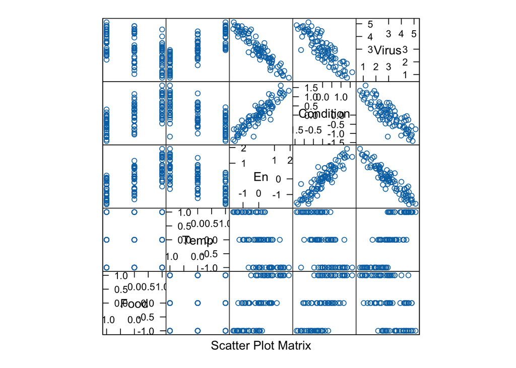

```r
# Finally, let's visualize our fake data (everything but the Reps column)
lattice::splom(expt[,-1])
```

It’s interesting to see that there is a clear, negative correlation between body condition and virus titers. I could imagine I might have seen these data and been very tempted to include body condition as a predictor of virus titers. Let’s try fitting two different models:

1. `Virus ~ Food + Temp`
2. `Virus ~ Food + Temp + Condition`

I’m going to use `quap()` and fairly vague (and unconsidered) priors.

```r
# correct model for total effect of food
mF <- quap(
  alist(
    Virus ~ dnorm(mu, sigma),
    mu <- a + bf*Food,
    # priors
    a ~ dnorm(3, 3),
    bf ~ dnorm(0, 1),
    sigma ~ dexp(1)
  ), data = expt
)
# Food and condition
mFC <- quap(
  alist(
    Virus ~ dnorm(mu, sigma),
    mu <- a + bf*Food + bc*Condition,
    # priors
    a ~ dnorm(3, 3),
    bf ~ dnorm(0, 1),
    bc ~ dnorm(0, 1),
    sigma ~ dexp(1)
  ), data = expt
)
# correct model for total effect of temperature
mT <- quap(
  alist(
    Virus ~ dnorm(mu, sigma),
    mu <- a + bt*Temp,
    # priors
    a ~ dnorm(3, 3),
    bt ~ dnorm(0, 1),
    sigma ~ dexp(1)
  ), data = expt
)
# temperature and condition
mTC <- quap(
  alist(
    Virus ~ dnorm(mu, sigma),
    mu <- a + bt*Temp + bc*Condition,
    # priors
    a ~ dnorm(3, 3),
    bt ~ dnorm(0, 1),
    bc ~ dnorm(0, 1),
    sigma ~ dexp(1)
  ), data = expt
)
# both food and temperature
mFT <- quap(
  alist(
    Virus ~ dnorm(mu, sigma),
    mu <- a + bf*Food + bt*Temp,
    # priors
    a ~ dnorm(3, 3),
    bf ~ dnorm(0, 1),
    bt ~ dnorm(0, 1),
    sigma ~ dexp(1)
  ), data = expt
)
# everything in!
mFTC <- quap(
  alist(
    Virus ~ dnorm(mu, sigma),
    mu <- a + bf*Food + bt*Temp + bc*Condition,
    # priors
    a ~ dnorm(3, 3),
    bf ~ dnorm(0, 1),
    bt ~ dnorm(0, 1),
    bc ~ dnorm(0, 1),
    sigma ~ dexp(1)
  ), data = expt
)
```

We should, of course, do more than simply look at coefficients in a real model, but for now this is informative.

```r
precis(mF)
```

```
            mean         sd       5.5%      94.5%
a      3.0175610 0.10273973  2.8533631  3.1817589
bf    -0.6367345 0.12492626 -0.8363908 -0.4370782
sigma  0.9752467 0.07211162  0.8599984  1.0904950
```

```r
precis(mFC)
```

```
            mean         sd         5.5%      94.5%
a      3.0460688 0.05929260  2.951307740  3.1408298
bf     0.1415279 0.09295413 -0.007030728  0.2900866
bc    -1.4594339 0.10839451 -1.632669284 -1.2861985
sigma  0.5622504 0.04172491  0.495565899  0.6289348
```

```r
precis(mT)
```

```
           mean         sd      5.5%     94.5%
a     3.0175542 0.06759806 2.9095194 3.1255889
bt    1.1054609 0.08253645 0.9735517 1.2373700
sigma 0.6414543 0.04756126 0.5654423 0.7174664
```

```r
precis(mTC)
```

```
            mean         sd       5.5%      94.5%
a      3.0353123 0.04220329  2.9678632  3.1027613
bt     0.6332245 0.06525103  0.5289408  0.7375082
bc    -0.9085481 0.07611415 -1.0301932 -0.7869030
sigma  0.4001668 0.02972630  0.3526584  0.4476752
```

```r
precis(mFT)
```

```
            mean         sd       5.5%      94.5%
a      3.0175824 0.03870723  2.9557207  3.0794440
bf    -0.6453735 0.04735772 -0.7210603 -0.5696867
bt     1.1105319 0.04735869  1.0348436  1.1862202
sigma  0.3672396 0.02728524  0.3236325  0.4108467
```

```r
precis(mFTC)
```

```
            mean         sd       5.5%      94.5%
a      3.0256093 0.03606916  2.9679638  3.0832547
bf    -0.4236474 0.07289250 -0.5401437 -0.3071511
bt     0.8948863 0.07166523  0.7803514  1.0094212
bc    -0.4112428 0.10760432 -0.5832152 -0.2392703
sigma  0.3416256 0.02539098  0.3010459  0.3822053
```

A graph can be helpful. This is command is useful:

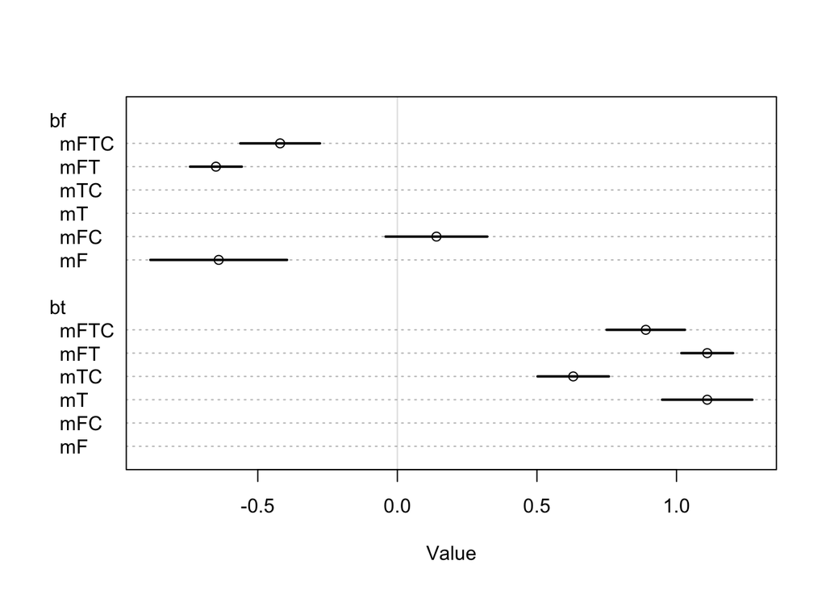

```r
plot(coeftab(mF, mFC, mT, mTC, mFT, mFTC), pars = c("bf", "bt"))
```

(If that doesn’t work, try the following…)

```r
coeftab_plot(coeftab(mF, mFC, mT, mTC, mFT, mFTC), pars = c("bf", "bt"))
```

It sure seems like when we include body condition we erode the estimates of food and temperature on viral titers. (If we include both food and temperature we get the same average effect sizes, but estimated with a bit more precision! Who knew?). This is probably because much of the effect of food and temperature works through energy reserves (En), and we’re conditioning on its descendant, body condition (Condition). So we’re already accounting for much of this path of influence, leaving much less for the food and temperature variables to explain. There is also the issue that the *sign* of the effect of food on virus is *reversed* if we include body condition in the model `mFC`. Crazy!

Thus, depending on the model we run we can get strikingly different results! But notice that there are no particular signs that this is not the “correct” model for our purposes! It fit just fine and it predicts the data just fine.

In fact, let’s see what the models tell us viral titers should be. We created functions to facilitate this last week. Let’s load them back in.

```r
genPreds <- function(df, model, n=1e4, lo=0.055, hi=0.945){
  # use link to generate preds
  preds <- rethinking::link(fit=model, data=df, n=n)
  # find average across preds for each column
  df$preds_mean <- apply(X=preds, MARGIN=2, FUN = mean)
  # find lower CI and add to df
  df$preds_lo <- apply(X=preds, MARGIN=2, FUN = quantile, prob=lo)
  # find upper CI and add to df
  df$preds_hi <- apply(X=preds, MARGIN=2, FUN = quantile, prob=hi)
  # return the data frame
  return(df)
}

genPPD <- function(df, model, n=1e4, lo=0.055, hi=0.945){
  # use sim to generate predicted observation
  obs <- rethinking::sim(fit=model, data=df, n=n)
  # find lower quantile of predicted observations for each column
  df$PPD_lo <- apply(X=obs, MARGIN=2, FUN = quantile, prob=lo)
  # find upper quantile of predicted observations for each column
  df$PPD_hi <- apply(X=obs, MARGIN=2, FUN = quantile, prob=hi)
  # return df
  return(df)
}
```

Now we can use these to generate mean predicted values for each combination of treatment values as well as the posterior predicted intervals. The hard part is honestly getting things to plot somewhat nicely Model 1

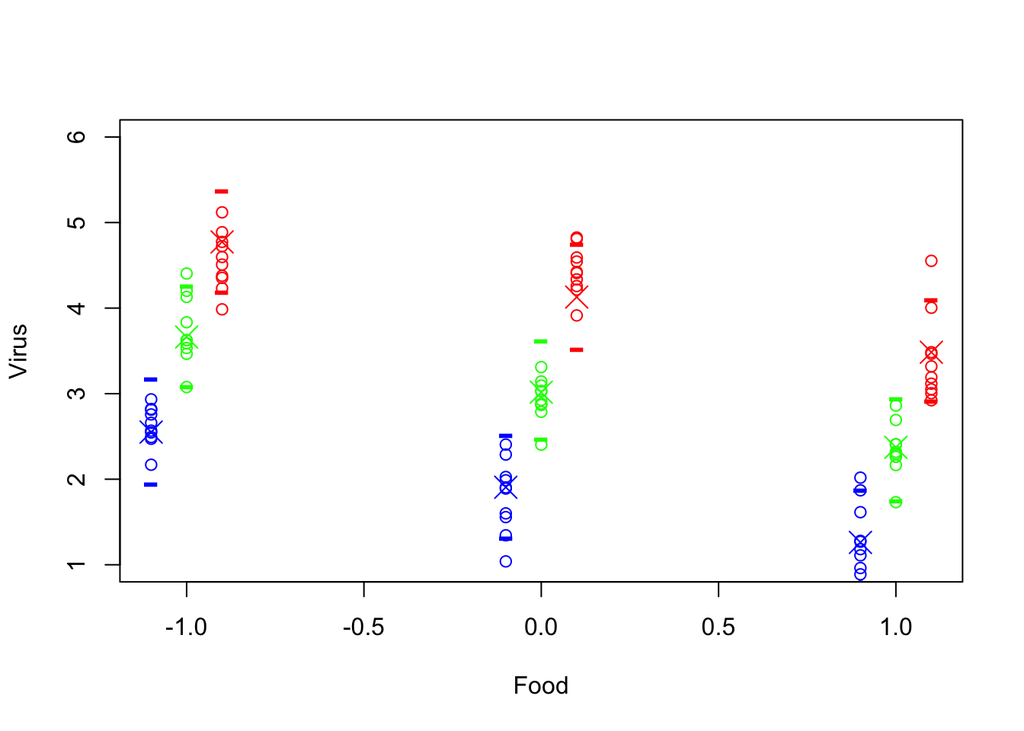

```r
dfpreds <- genPreds(df = expt[expt$Reps==1,],
                    model = mFT,
                    n = 1000)
dfpreds <- genPPD(df = dfpreds,
                  model = mFT,
                  n = 1000)

plot(Virus ~ I(Food+Temp/10), # <- a trick to get them side-by-side
     col = c("blue","green","red")[Temp + 2],
     xlab = "Food",
     ylim = c(1, 6),
     data = expt)
# means
points(x=I(dfpreds$Food+dfpreds$Temp/10),
       y=dfpreds$preds_mean,
       col = c("blue","green","red")[dfpreds$Temp + 2],
       pch = 4, cex = 2)
# lower PPD
points(x=I(dfpreds$Food+dfpreds$Temp/10),
       y=dfpreds$PPD_lo,
       col = c("blue","green","red")[dfpreds$Temp + 2],
       pch = "-", cex = 2)
# upper PPD
points(x=I(dfpreds$Food+dfpreds$Temp/10),
       y=dfpreds$PPD_hi,
       col = c("blue","green","red")[dfpreds$Temp + 2],
       pch = "-", cex = 2)
```

Model 2

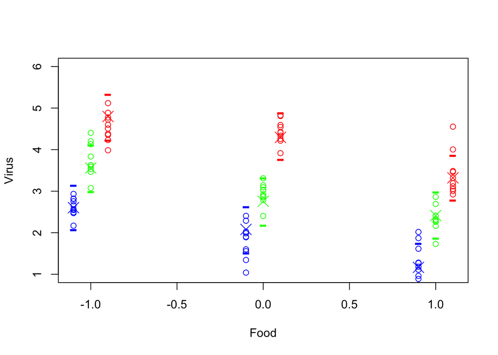

```r
dfpreds <- genPreds(df = expt[expt$Reps==1,],
                    model = mFTC,
                    n = 1000)
dfpreds <- genPPD(df = dfpreds,
                  model = mFTC,
                  n = 1000)

plot(Virus ~ I(Food+Temp/10), # <- a trick to get them side-by-side
     col = c("blue","green","red")[Temp + 2],
     xlab = "Food",
     ylim = c(1, 6),
     data = expt)
# means
points(x=I(dfpreds$Food+dfpreds$Temp/10),
       y=dfpreds$preds_mean,
       col = c("blue","green","red")[dfpreds$Temp + 2],
       pch = 4, cex = 2)
# lower PPD
points(x=I(dfpreds$Food+dfpreds$Temp/10),
       y=dfpreds$PPD_lo,
       col = c("blue","green","red")[dfpreds$Temp + 2],
       pch = "-", cex = 2)
# upper PPD
points(x=I(dfpreds$Food+dfpreds$Temp/10),
       y=dfpreds$PPD_hi,
       col = c("blue","green","red")[dfpreds$Temp + 2],
       pch = "-", cex = 2)
```

**Your turn!**

Let’s go one step further… Imagine that you *could* observed energy reserves directly. First modify the DAG so that `En` is now observed and see if or how the adjustment sets change for the total and direct effects of temperature and food on viral titers. Second, include the term `En` in your model (we’ve already simulated it, right?) and see how the estimates change for parameters `bf` and `bt`. What effect does adding `En` to the rest of the variables (`Food`, `Temp`, and `Condition`) on our estimates of the coefficients for food and temperature?

```r
#First
```

```r
#Second
```

# Example 2: An observational study

Let’s re-imagine our study as an observational one instead of an experiment. In this case, we might expect temperature to affect the availability of food, too.

**Your turn, part 1!**

First, revise the DAG, from above, to include this arrow from Temp to Food. Let’s again assume that energy reserves (En) are unobserved. According to the DAG, what should we condition on to understand the total effect of food on virus titers? Of temperature on virus titers? Can we estimate the *direct* effect of temperature on virus, given this DAG?

The next step is to simulate data from this new model. We’ll have to think a bit more about how to do this in an observational study.

Let’s imagine we went out and measured the temperature and food availability in 30 ponds[^3], then collected a group of tadpoles from each pond, recorded their *average* body condition, and exposed them to the virus of interest and measured the *average* viral concentration in the tadpoles. Thus, we have one observation of each variable in each of the 30 ponds.

We’ll also assume that the prior experiments were conducted such that $\pm 1$ meant $\pm 1$ standard deviation. Thus we can use the same effect sizes as before and they should mean the same thing.

**Your turn, Part 2**

1. Establish a bunch of random temperatures (they are no longer set by the experimenter) around the mean temperature, which we’ll center at zero and with a standard deviation of 1.
2. Simulate a bunch of food availability, given some effect of temperature on food (again, centered so that the mean food availability is zero)
3. Simulate energy reserves given temperature and food (for easy comparison, keep the effects the same as before)
4. Simulate body condition and virus titers.
5. Plot a scatter plot matrix to observe your fake data

```r
n = 30
# step 1

# step 2

# step 3

# step 4

# step 5
```

With your simulated data, let’s fit some models to see how much our estimates of *total* effect sizes of food and temperature are influenced by using the correct and incorrect adjustments.

**Your turn, Part 3**

1. Fit the correct (per the `adjustmentSets()` function) models to find the appropriate estimates of the total effect of temperature on viral titers.
2. Fit at least one other model you think you might have fit had you not been knee-deep in DAG-thinking.
3. Compare the estimated effect size (i.e., coefficient for temperature) between the models. Describe what changed and, to the best of your abilities, why it changed.
4. Repeat for the total effect of *food* on viral titers

```r
# step 1
```

```r
# step 2
```

```r
# step 3
```

```r
# step 4
```

## Footnotes

[^1]: Amphibian larvae perhaps?
[^2]: Ignoring the temperature-dependence of the host’s immune response.
[^3]: I’m apparently incapable of providing a non-amphibian example!